# レポート(深層学習:Day1,Day2)

## ■Day1

DNNの目的は、

- 誤差を最小化するパラメータを発見すること
- 結果的には重みとバイアスの値が最適化される

### 回帰と分類

- 回帰→連続する実数値をとる関数の近似
  - 線形回帰
  - 回帰木→内部節点は変数に対応し、子節点への枝はその変数の取り得る値を示す
  - ランダムフォレスト→ ランダムサンプリングされたトレーニングデータによって学習した多数の決定木を使用する方法
  - ニューラルネットワーク(NN)
- 分類→離散的な結果を予想するための分析
  - ベイズ分類
  - ロジスティック回帰
  - 決定木(分類木)→データマイニングでよく使われる。葉が分類を表す。
  - ランダムフォレスト
  - ニューラルネットワーク(NN)

### Section1) 入力層～中間層

- 入力層は、必ず1層。中間層は任意。
- 入力データと重みの積にバイアスを加算したものが、中間層の入力になる。  
  $ u1 = w_1 x_1 + w_2 x_2 \cdots + w_n x_n +b1 $  
  u1 = np.dot(x,W1) +b1 ( for Python)

### Section2) 活性化関数

- 中間層用の活性化関数
  - ReLU関数→一番よく使われている。勾配消失問題の回避とスパース化(パラメータのほとんどを0にすることで計算量を減らす)に貢献
  - シグモイド関数→勾配消失問題を引き起こす場合がある
  - ステップ関数 → 0,1の2値で表現。線形分離可能なものしか学習できなかった。

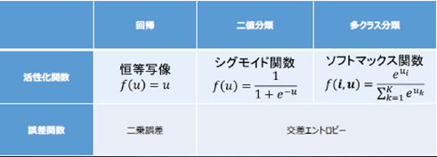

### Section3) 出力層

#### 3-1 誤差関数

- 誤差関数とは、ネットワークで予測された値と、正解(教師データ)との差を定量化する為の関数。
- 回帰では「二乗誤差」、分類では、「公差エントロピー」を使う

#### 3-2 出力層の活性化関数

- 出力層と中間層では、利用される活性化関数が異なる
- 出力層用の活性化関数
  - ソフトマックス関数→出力値を0～1の範囲に限定し、総和が1になる。
  - 恒等関数→入力値をそのまま出力する
  - シグモイド関数

### Section4) 勾配降下法

勾配降下法とは、誤差関数の勾配に学習率を掛けて重み・バイアスを最適化する方法

- 学習率について
  - 大きすぎる→ 発散する
  - 小さすぎる→ 収束に時間がかかる、局所解に落ち着くリスクがある。 - 収束性向上のアルゴリズム(Adamなど)がある
- 勾配降下法のいろいろ

| 名称 | 誤差の特徴 | メリット |
| --- | --- | --- |
| 勾配降下法 | 全サンプルの平均誤差 |  |
| 確率的勾配降下法(SGD) | ランダムに抽出したサンプルの誤差 | 計算コストの削減 局所極小解に収束するリスクの軽減 オンライン学習 |
| ミニバッチ勾配降下法 | ランダムに分割したデータの集合に属するサンプルの平均誤差 | スレッド並列化当により計算資源の有効活用が可能 |

数値微分とは、プログラムで微笑な数値を生成擬似的に微分計算する方法。計算に時間がかかるが実装は容易。

### Section5) 誤差逆伝播法

- 重みパラメータの勾配の計算を効率よく行う方法。
- 算出された誤差を、出力層から順に微分し、前の層・前の層へと伝播することで、パラメータを最適化する。

## ■Day2

### ■深層モデルのための学習テクニック

### Section1) 勾配消失問題

- 勾配消失問題→誤差逆伝播法が下位層に進むにつれてパラメータの更新が進まなくなること
- 特にシグモイド関数で発生しやすい
- 解決方法として
  - 活性化関数の選択
  - 重みの初期値設定
  - バッチ正規化

#### 1.1 活性化関数

ReLU関数を使うことで、勾配消失を起きづらくできる

#### 1.2 重みの初期値設定

- 重みの初期値をすべて"0"にすると、すべてのノードでの重みの学習が同じになり、  
  たくさんの重みをもつ意味がなくなる→重みの非対称性な構造が重要
- Xavier→重みの要素を、前の層のノード数の平方根で除算した値
- He→重みの要素を、前の層のノード数の平方根で除算した値に対し、√2を掛けた値

Xavierが適した活性化関数

- ReLU関数
- シグモイド関数※
- 双曲線正接関数(tanh)※

Heが適した活性化関数

- ReLU関数※

#### 1-3 バッチ正規化(Batch Normalization)

- ミニバッチ単位で、入力値のデーアの偏りを抑制する手法
- 活性化関数の値を渡す前後に、バッチ正規化の処理を行う層を追加する

バッチ正規化を実施することで、

- 学習の高速化
- 勾配消失がおきづらくなる
- 過学習を抑制できる
- 重みの初期値にそれほど依存しない  
  等の効果を得ることができる

### Section2) 学習率最適化手法について

- 学習率が大きいと、最適値にたどりつかず発散してしまう
- 学習率は小さいと、学習が遅くなり、大域局所最適解に収束しづらくなる

学習率最適化手法とは、学習率を最適化するための手法

#### 2-1 モメンタム

- 勾配が大きいときは大きく、小さいときは小さくなるように設定する方法
- 通常の勾配降下法に対し、前回の重みを減算した値と慣性(パラメータ)の積を加算する

$ \hspace{10mm} V_t = \mu V_(t-1) - \eta \nabla E \hspace{10mm} 慣性:\mu$  
$ \hspace{10mm} W^(t+1) = W^(t) + V_t $

- 大域的最適化になる
- (谷間についてからの最適値にいくまでの)学習の速度が速い

#### 2-2 AdaGrad

- 学習が進むにつれて、学習率を小さくする方法
- 通常の勾配降下法に対し、最定義した学習率の積を減算する  
  →これにより、よく動いたパラメータの学習係数は、より小さくなる

$ \hspace{10mm} h_0 = \theta \hspace{10mm} \thetaは小さい値 $  
$ \hspace{10mm} h_t = h_{t-1} + ( \nabla E)^2 $  
$ \hspace{10mm} W^{(t+1)} = W^(t) - \varepsilon \frac{1}{\sqrt{h_t} + \theta} \nabla E $

- 鞍点問題(ある方向から見れば極小だが、ある方向で見れば極大になる点)を引き起こす事がある

#### 2-3 RMSProp

- AdaGradを改善した手法

$ \hspace{10mm} h_t = \alpha h_{t-1} +(1-\alpha) ( \nabla E)^2 $  
$ \hspace{10mm} W^{(t+1)} = W^(t) - \varepsilon \frac{1}{\sqrt{h_t} + \theta} \nabla E $

- パラメータの調整が少なくて済む

#### 2-4 Adam

- モメンタムとAdaGradのアイディアを融合した手法

### Section3) 過学習について

- 過学習とは、訓練データだけに適応しすぎてしまい、他のデータ(テストデータ)にうまく適応できない状態
- 発生する原因としては、
  - ネットワークの自由度が高い(パラメータが多い、ノードが多い)
  - 訓練データが少ない

#### 3-1 L1正則化、L2正則化

- 正則化とは、ネットワークの自由度(層数、ノード数、パラメータの値等)を制約すること
- Weight decay(荷重減衰)→過学習の原因となりやすい大きい値の重みに対し、正則化項を加算し重みを抑制する手法

追加する正則化項としては、

- L1正則化→ラッソ回帰
- L2正則化→リッジ回帰

$ \hspace{10mm} 損失関数 → E_n(W)+ \frac{1}{p} ||x||_p \hspace{10mm} pノルムを加える$  
$ \hspace{10mm} ||x||_p = (|x_1|^p + \cdots + |x_n|^p) ^\frac{1}{p} \hspace{10mm} p=1の時、L1正則化、 p=2の時、L2正則化 $

#### 3.2 ドロップアウト

- ノード数が多い場合に有効な、過学習対策手法
- ランダムにノード数を削除して学習させる
- データ量を変化させずに、異なるモデルを学習させていると解釈できる

### ■畳み込みニューラルネットワークについて

### Section4) 畳み込みニューラルネットワークの概念、全体像(CNNの構造図)

Convolutionレイヤ(畳み込み層)とPoorlongレイヤ(プーリング層）が追加される

#### 4-1 畳み込み層

- 畳み込み層によって、3次元データの形状を維持できるようになる
- 処理は、入力データにフィルタを適用し、その乗算の和を出力する
- バイアス → 入力データとフィルタから出力された計算結果に加算されるパラメータ
- パティング → 入力データの周辺に固定のデータを追加する
- ストライド → フィルタを適用する位置の間隔
- チャンネル → 奥行き方向のデータ。入力データとフィルタのチャンネル数は同じにする

出力されるサイズは以下で計算される  
$ \hspace{10mm} OH = \frac{H+2P-FH}{S} +1 $  
$ \hspace{10mm} OW = \frac{W+2P-FW}{S} +1 $  
$ \hspace{10mm} 入力サイズ=(H, W), フィルタサイズ=(FH, FW), パディング=P, ストライド=S $

- im2col関数を使うことで、多次元データを容易に2次元の配列に変換できる
- 2次元データを多次元に戻すcol2imという関数があるが、不可逆変換なので注意が必要。

#### 4-1 プーリング層

- 縦・横方向の空間を小さくする
- Maxプーリング(領域の最大値)とAverageプーリング(領域の平均値)がある

※プーリング層の特徴

- 学習パラメータがない
- チャンネル数は変化しない
- 微小な位置変化に対してロバスト(頑健)

### Section5) 最新のCNN

#### 5-1 AlexNet

- 5層の畳み込み層およびプーリング層、それにつづく3層の全結合層から構成される
- 過学習を防ぐ施策として、全結合型の出力にドロップアウトを使用している